# Avaliação

▪ Dados: qualidade do sono e estilo de vida

▪ Atividade 3 (individual): considere que os dados utilizados nessa aula são referentes a uma pesquisa realizada pela área de recursos humanos (RH) de uma empresa com uma amostra de seus colaboradores. O objetivo da empresa é entender como está a qualidade do sono e estilo de vida de seus colaboradores e, a partir disso, criar estratégias que promovam a saúde mental. Utilizando apenas o conteúdo abordado até agora, que recomendações/sugestões você daria à área de RH?

# Resumo

*Gerado com IA com base na análise*

A análise dos dados revelou que 41% dos colaboradores apresentam algum tipo de desordem do sono, sendo divididos igualmente entre Apneia do Sono (78 casos) e Insônia (77 casos). Esse dado demonstra um sinal de alerta em relação à qualidade do descanso da equipe.

Em relação ao estresse, observa-se que a maioria dos colaboradores apresenta níveis moderados a altos de estresse, com metade deles posicionados entre os níveis 4 e 7. Por outro lado, não foram identificados casos críticos próximos ao burnout.

A análise por áreas revelou cenários distintos:

Saúde: concentra 57% dos casos de alto estresse da empresa, distribuídos igualmente entre Médicos e Enfermeiros.

Vendas: apresenta um quadro preocupante, onde 100% dos colaboradores estão com alto nível de estresse, embora representem menos de 30% dos casos gerais.

Engenharia: se destaca como a área com o melhor equilíbrio emocional, apresentando maioria dos colaboradores com baixo nível de estresse.

Quanto à qualidade do sono, há uma variação relevante entre as ocupações. Profissionais das áreas de vendas, ciência e enfermagem apresentam as menores médias de horas de sono. Apesar de pertencerem à mesma área, observa-se uma diferença significativa nas horas de sono entre Médicos e Enfermeiros, o que sugere rotinas e demandas distintas.

Além disso, ficou evidente que colaboradores com níveis mais altos de estresse dormem, em média, até 2 horas a menos por dia, quando comparados a colegas com baixo estresse.

Por fim, ao observar a relação com pressão arterial, destaca-se que colaboradores classificados como “Hipertensão Nível 2” têm as menores médias de sono, enquanto aqueles nos grupos “Normal” e “Elevado” apresentam uma maior consistência, dormindo entre 7 e 8 horas, faixa recomendada pela Organização Mundial da Saúde (OMS).

# Análise

### 1. Quali

**Desordem do sono**

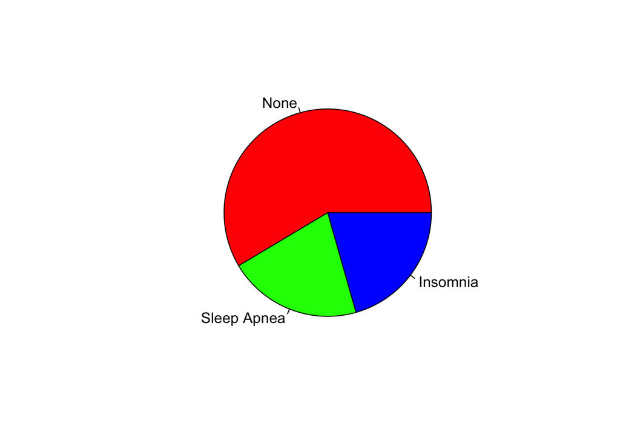

| Tem desordem do sono? | Quantidade |
| --- | --- |
| Não | 219 |
| Sim | 155 |

| Tem desordem do sono? | % |
| --- | --- |
| Não | 59 |
| Sim | 41 |

| Qual desordem? | Quantidade |
| --- | --- |
| Sleep Apnea | 78 |
| Insomnia | 77 |

| Qual desordem? | % |
| --- | --- |
| Sleep Apnea | 50 |
| Insomnia | 50 |

### 2. Quanti

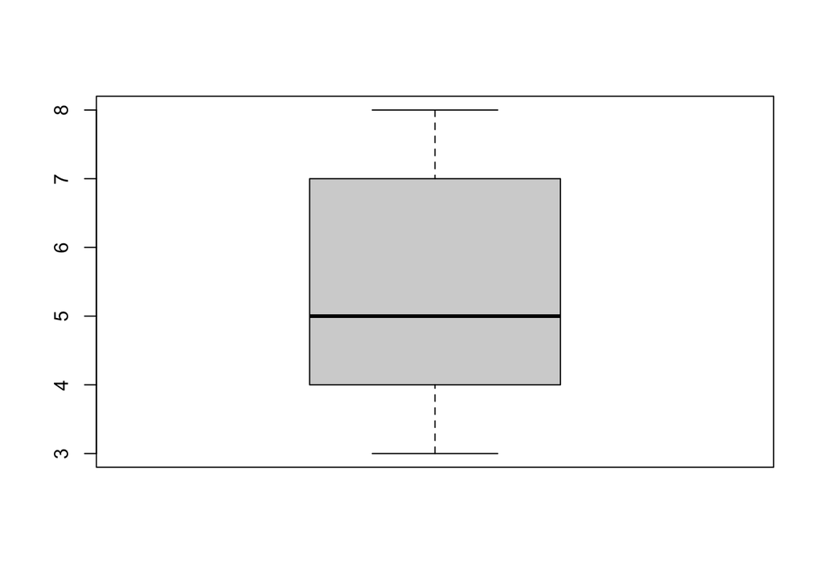

| Statistic | Value |
| --- | --- |
| Min. | 3.00 |
| 1st Qu. | 4.00 |
| Median | 5.00 |
| Mean | 5.39 |
| 3rd Qu. | 7.00 |
| Max. | 8.00 |
| SD | 1.77 |

Analisando o nível de estresse reportado pelos colaboradores, é possível perceber que há um nível de estresse de moderado a alto dentro da empresa. Sendo que temos metade dos colaboradores reportando nível de estresse entre 4 e 7, considerados médios. Com base nesta pesquisa, não temos colaboradores que estejam próximos de burnout.

### 3. Quali x Quali

**Profissão** x **Nível de Estresse**

|  | Baixíssimo | Baixo | Médio | Alto | Horrível |
| --- | --- | --- | --- | --- | --- |
| Accountant | 0 | 2 | 29 | 6 | 0 |
| Engineering | 0 | 34 | 29 | 4 | 0 |
| Health | 0 | 35 | 40 | 69 | 0 |
| Lawyer | 0 | 0 | 47 | 0 | 0 |
| Manager | 0 | 0 | 1 | 0 | 0 |
| Sales | 0 | 0 | 0 | 34 | 0 |
| Scientist | 0 | 0 | 2 | 2 | 0 |
| Teacher | 0 | 0 | 35 | 5 | 0 |

|  | Baixíssimo | Baixo | Médio | Alto | Horrível |
| --- | --- | --- | --- | --- | --- |
| Accountant | 0 | 5 | 78 | 16 | 0 |
| Engineering | 0 | 51 | 43 | 6 | 0 |
| Health | 0 | 24 | 28 | 48 | 0 |
| Lawyer | 0 | 0 | 100 | 0 | 0 |
| Manager | 0 | 0 | 100 | 0 | 0 |
| Sales | 0 | 0 | 0 | 100 | 0 |
| Scientist | 0 | 0 | 50 | 50 | 0 |
| Teacher | 0 | 0 | 88 | 12 | 0 |

|  | Baixíssimo | Baixo | Médio | Alto | Horrível |
| --- | --- | --- | --- | --- | --- |
| Accountant | NaN | 3 | 16 | 5 | NaN |
| Engineering | NaN | 48 | 16 | 3 | NaN |
| Health | NaN | 49 | 22 | 57 | NaN |
| Lawyer | NaN | 0 | 26 | 0 | NaN |
| Manager | NaN | 0 | 1 | 0 | NaN |
| Sales | NaN | 0 | 0 | 28 | NaN |
| Scientist | NaN | 0 | 1 | 2 | NaN |
| Teacher | NaN | 0 | 19 | 4 | NaN |

|  | Baixíssimo | Baixo | Médio | Alto | Horrível |
| --- | --- | --- | --- | --- | --- |
| Accountant | 0 | 2 | 29 | 6 | 0 |
| Doctor | 0 | 4 | 34 | 33 | 0 |
| Engineer | 0 | 34 | 29 | 4 | 0 |
| Lawyer | 0 | 0 | 47 | 0 | 0 |
| Manager | 0 | 0 | 1 | 0 | 0 |
| Nurse | 0 | 31 | 6 | 36 | 0 |
| Sales | 0 | 0 | 0 | 34 | 0 |
| Scientist | 0 | 0 | 2 | 2 | 0 |
| Teacher | 0 | 0 | 35 | 5 | 0 |

Com base na pesquisa feita com os colaboradores, temos que as áreas de Saúde e Vendas têm os níveis mais alarmantes de estresse entre os seus integrantes. Dentro da área da saúde, temos 57% das pessoas com alto nível de estresse da empresa, sendo metade sendo de Médicos e metade sendo de Enfermeiros. Dentro da área de vendas, apesar de termos pouco menos de 30% da quantidade total de pessoas com alto nível de estresse, dentro desta área possuímos apenas colaboradores com alto nível de estresse. A área de engenharia tem a melhor distribuição de nível de estresse, tendo mais da maioria de seus integrantes com um nível baixo de estresse.

### 4. Quali x Quanti

**Ocupação** x **Duração do Sono**

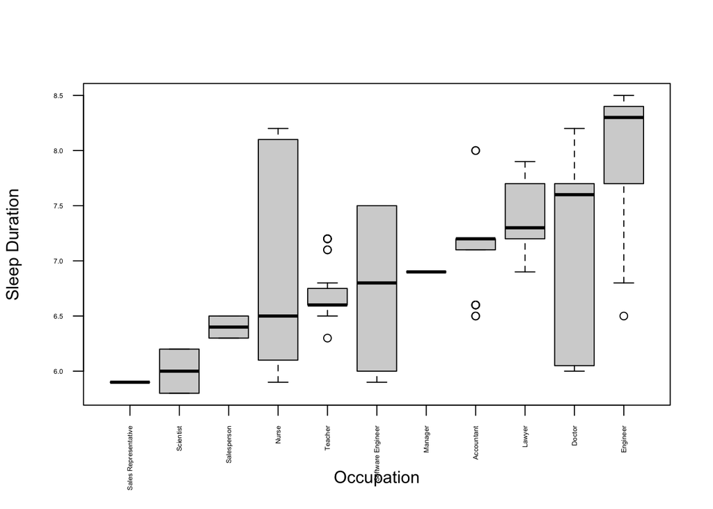

| Occupation | Median |
| --- | --- |
| Sales Representative | 5.9 |
| Scientist | 6.0 |
| Salesperson | 6.4 |
| Nurse | 6.5 |
| Teacher | 6.6 |
| Software Engineer | 6.8 |
| Manager | 6.9 |
| Accountant | 7.2 |
| Lawyer | 7.3 |
| Doctor | 7.6 |
| Engineer | 8.3 |

Temos uma grande variação de horas de sono entre as profissões, temos que as profissões relacionadas à área de vendas, ciência e enfermaria tendem a ter menos horas de sono se comparadas com as demais profissões. Apesar de fazerem parte da mesma área, Médicos e Enfermeiros tem um diferença significativa em suas horas de sono.

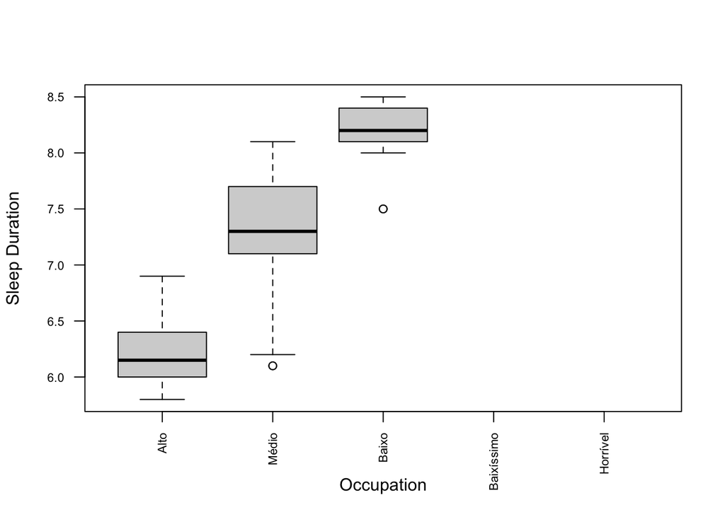

```r
boxplot(
  dados$Sleep.Duration ~ reorder(dados$Stress.Level.Adj, dados$Sleep.Duration, median),
  ylab = "Sleep Duration",
  xlab = "Occupation",
  las = 2,
  cex.axis = 0.7
)
```

```r
knitr::kable(
  dados %>%
    group_by(Stress.Level.Adj) %>%
    summarize(Median = median(Sleep.Duration)) %>%
    arrange(Median)
)
```

| Stress.Level.Adj | Median |
| --- | --- |
| Alto | 6.15 |
| Médio | 7.30 |
| Baixo | 8.20 |

Temos também que pessoas mais estressadas, têm até 2h a menos de sono diariamente, se comparadas a pessoas com um nível de estresse baixo.

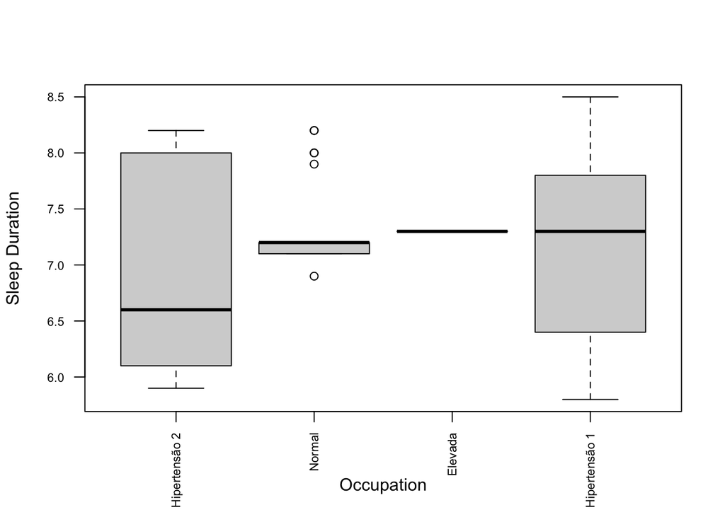

| Blood.Pressure.Adj | Median |
| --- | --- |
| Hipertensão 2 | 6.6 |
| Normal | 7.2 |
| Elevada | 7.3 |
| Hipertensão 1 | 7.3 |

Temos também que colaboradores que, segundo o American College of Cardiology, estão no nível de Hipertensão Nível 2, dormem menos do que os outros grupos. Temos também que pessoas nos grupos “Normal” e “Elevado” têm mais consistência de horas de sono dormidas, estando entre as 7 e 8 horas estabelecidas pela OMS.